# Администрирование сетевых подсистем

Лабораторная работа №13

Тойчубекова Асель Нурлановна

kulyabov-ds@rudn.ru

Российский университет дружбы народов

2025-11-29

# Информация

## Докладчик

- Тойчубекова Асель Нурлановна
- Студент 3 курса
- факультет физико-математических и естественных наук
- Российский университет дружбы народов им. П. Лумумбы
- 1032235033@rudn.ru

# Цель работы

## Цель работы

Целью данной лабораторной работы является приобретение навыков настройки сервера NFS для удалённого доступа к ресурсам.

# Задание

## Задание

1. Установите и настройте сервер NFSv4.
2. Подмонтируйте удалённый ресурс на клиенте.
3. Подключите каталог с контентом веб-сервера к дереву NFS.
4. Подключите каталог для удалённой работы вашего пользователя к дереву NFS.
5. Напишите скрипты для Vagrant, фиксирующие действия по установке и настройке сервера NFSv4 во внутреннем окружении виртуальных машин server и client.Соответствующим образом внесите изменения в Vagrantfile.

# Теоретическое введение

## Теоретическое введение

Протокол сетевого доступа к файловым системам NFS (Network File System) предназначен для организации работы с удалёнными файловыми ресурсами так, будто они находятся локально на клиентской машине. Работа NFS основана на клиент-серверной архитектуре: NFS-сервер предоставляет доступ к своим каталогам, а NFS-клиент может монтировать эти каталоги в собственное файловое пространство и взаимодействовать с ними без изменения настроек приложений.

## Теоретическое введение

Обмен данными между клиентом и сервером NFS осуществляется с использованием протокола RPC (Remote Procedure Call), который определяет формат всех запросов и ответов. Процесс монтирования и размонтирования NFS-ресурсов реализуется службами протокола Mount (mountd).

Для организации удалённого доступа необходимо выполнить два шага:

Экспортирование каталогов на сервере — сервер указывает, какие каталоги он делает доступными для клиентов и с какими правами. Эти параметры задаются в файле /etc/exports.

Монтирование экспортированных каталогов на клиенте — клиент подключает предоставленный сервером каталог в свою файловую систему и работает с ним как с локальным.

## Теоретическое введение

В конфигурации экспортирования можно задавать различные параметры доступа, такие как:

- ro/rw — права только чтения или чтения/записи;
- root_squash — понижение привилегий пользователя root клиента до пользователя nobody (включено по умолчанию);
- no_root_squash — полный доступ root-пользователя к удалённой системе (не рекомендуется);
- all_squash, anonuid, anongid — преобразование всех запросов к анонимному пользователю, что повышает безопасность.

## Теоретическое введение

По умолчанию пользователь root не имеет привилегированного доступа к удалённым NFS-каталогам: его UID преобразуется в UID пользователя nobody, что предотвращает риски нарушения целостности данных.

Для просмотра информации о смонтированных или экспортируемых NFS-ресурсах используется команда showmount, позволяющая просматривать удалённые монтирования и список экспортированных файловых систем.

# Выполнение лабораторной работы

## Настройка сервера NFSv4

Для начала лабораторной работы запустим вм server, зайдем под нашим пользователем откроем терминал и перейдем в режим суперпользователя. Установим необходимое программное обеспечение.

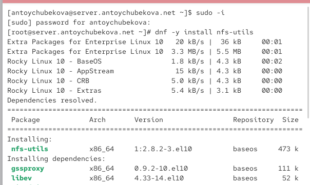

Установка программного обеспечения

## Настройка сервера NFSv4

На сервере создадим каталог, который предполагается сделать доступным всем пользователям сети (корень дерева NFS).

## Настройка сервера NFSv4

В файле /etc/exports пропишим подключаемый через NFS общий каталог с доступом только на чтение.

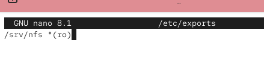

Подключение через NFS общий каталог

## Настройка сервера NFSv4

Для общего каталога зададим контекст безопасности NFS. И применим изменённую настройку SELinux к файловой системе.

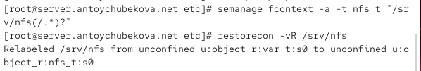

Задание контекста безопасности NFS

## Настройка сервера NFSv4

Запустим сервер NFS.

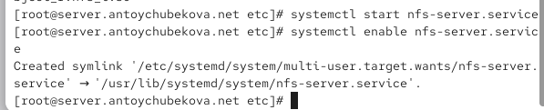

Запуск сервера NFS

## Настройка сервера NFSv4

Настроим межсетевой экран для работы сервера NFS.

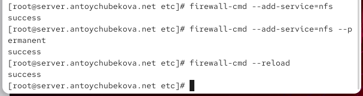

Настройка межсетевого экрана

## Настройка сервера NFSv4

На клиенте установим необходимое для работы NFS программное обеспечение.

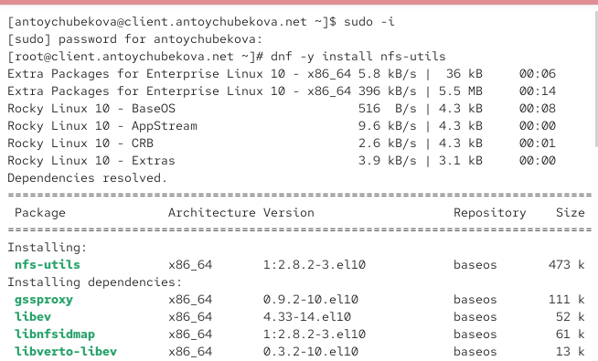

Установка программного обеспечения

## Настройка сервера NFSv4

На клиенте попробуем посмотреть имеющиеся подмонтированные удалённые ресурсы. Мы видим, что пока ничего нет. Клиент не смог получить ответ по RPC.

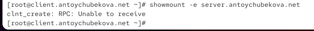

Подмонтированные удалённые ресурсы

## Настройка сервера NFSv4

Попробуем на сервере остановить сервис межсетевого экрана.

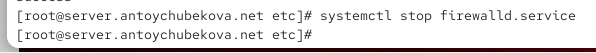

Остановка межсетевого эерана

## Настройка сервера NFSv4

Затем на клиенте вновь попробуем подключиться к удалённо смонтированному ресурсу. Мы видим, что после того как клиент обращается к серверу, сервер отвечает списком экспортируемых директорий, в данном случае экспортируется одна директория /srv/nfs с доступом для всех клиентов.

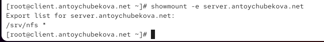

Подключение к удаленному ресурсу

## Настройка сервера NFSv4

На сервере запустим сервис межсетевого экрана.

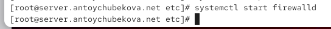

Запуск межсетевого экрана

## Настройка сервера NFSv4

На сервере посмотрим, какие службы задействованы при удалённом монтировании. Мы видим, что задействована служба rpc.

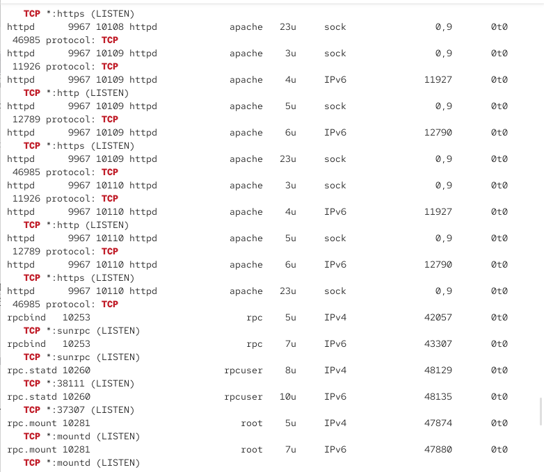

Службы задействованные при удаленном монтировании

## Настройка сервера NFSv4

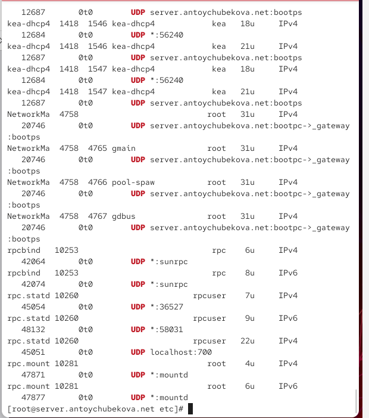

Службы задействованные при удаленном монтировании

## Настройка сервера NFSv4

Добавим службы rpc-bind и mountd в настройки межсетевого экрана на сервере. Для начала посмотрим все службы.

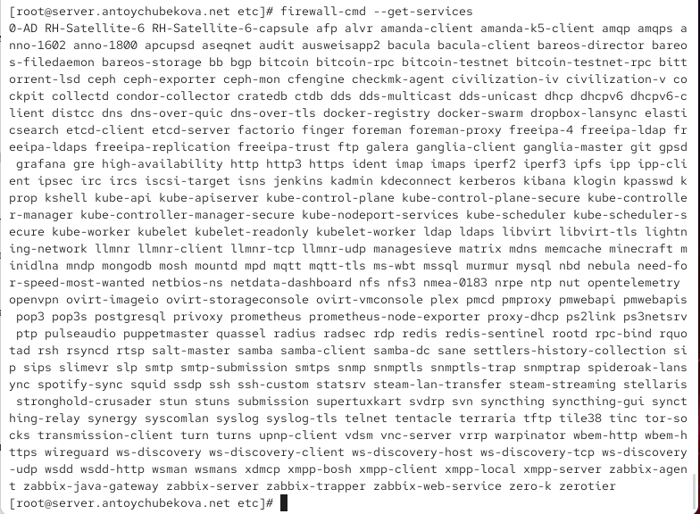

Просмотр всех служб

## Настройка сервера NFSv4

Далее добавим службу rpc-bind и mountd и перезапустим firewall.

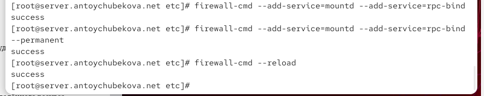

Добавление службы rpc

## Настройка сервера NFSv4

На клиенте проверим подключение удалённого ресурса. Мы видим, что все корректно обрабатывается.

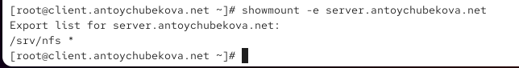

## Монтирование NFS на клиенте

На клиенте создадим каталог, в который будет монтироваться удалённый ресурс, и подмонтируем дерево NFS.

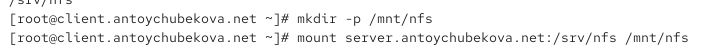

Создание и монтирование каталога

## Монтирование NFS на клиенте

Проверим, что общий ресурс NFS подключён правильно. Мы видим, что все работает правильно и общий ресурс NFS подключен.

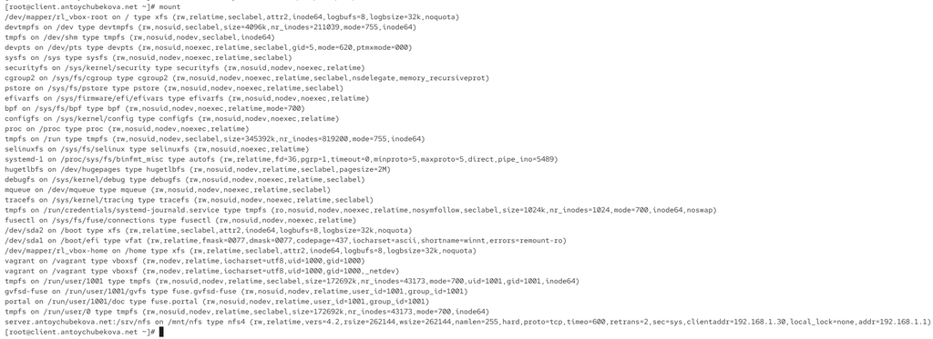

Подключение общего ресурса NFS

## Монтирование NFS на клиенте

Мы видим, что выводится информация-удалённый каталог /srv/nfs с сервера server.antoychubekova.net смонтирован на локальный узел в каталог /mnt/nfs по протоколу NFS версии 4.2. Монтирование выполнено в режиме чтения-записи через TCP, с крупными размерами блоков (256 KB), стандартной UNIX-аутентификацией и «жёстким» режимом (клиент будет ждать ответа сервера при сбоях). В выводе также указаны технические параметры подключения: тайм-ауты, число повторов и IP-адреса клиента и сервера.

## Монтирование NFS на клиенте

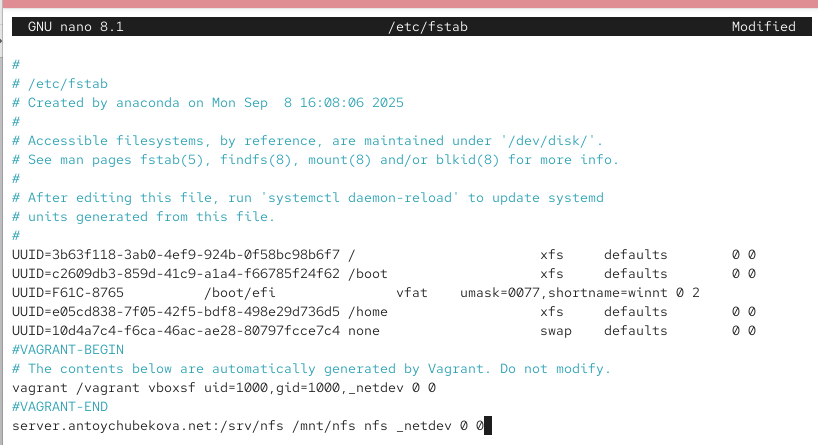

Подключение авто монтирования

## Монтирование NFS на клиенте

На клиенте проверим наличие автоматического монтирования удалённых ресурсов при запуске операционной системы. Мы видим, что все корректно обрабатывается.

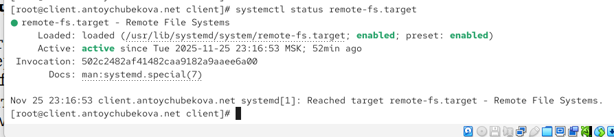

Проверка наличия автоматического монтирования

## Монтирование NFS на клиенте

Перезапустим клиента и убедимся, что удалённый ресурс подключается автоматически.

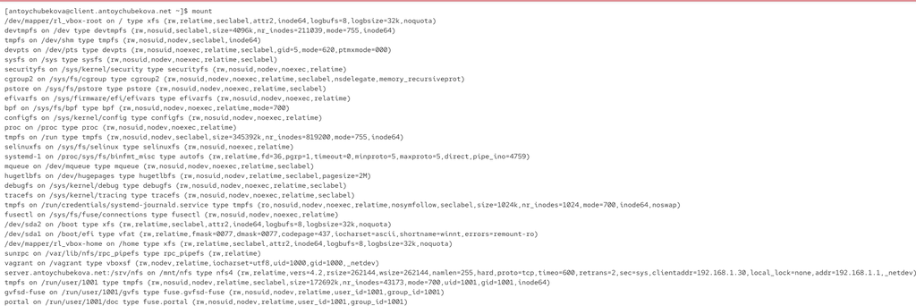

Проверка автоматического подключения

## Подключение каталогов к дереву NFS

На сервере создадим общий каталог, в который затем будет подмонтирован каталог с контентом веб-сервера. Подмонтируем каталог web-сервера.

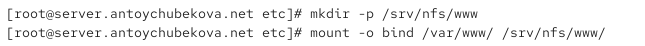

Монтирование каталога web-сервера

## Подключение каталогов к дереву NFS

На сервере проверим, что отображается в каталоге /srv/nfs. Мы видим, что у нас тут появился каталог www.

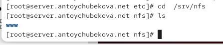

Содержимое каталога /srv/nfs

## Подключение каталогов к дереву NFS

На клиенте посмотрим, что отображается в каталоге /mnt/nfs. Мы видим, что у нас тут появился каталог www.

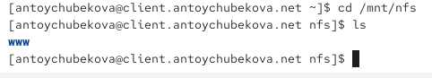

Содержимое каталога /mnt/nfs

## Подключение каталогов к дереву NFS

На сервере в файле /etc/exports добавим экспорт каталога веб-сервера с удалённого ресурса.

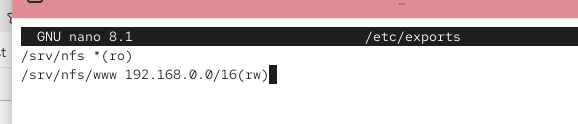

Экспорт каталога веб-сервера с удаленного ресурса

## Подключение каталогов к дереву NFS

Экспортируем все каталоги, упомянутые в файле /etc/exports.

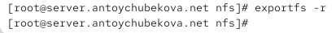

Экспорт каталогов

## Подключение каталогов к дереву NFS

Проверим на клиенте каталог /mnt/nfs. Мы видим, что у нас тут появился каталог www.

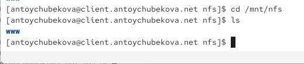

Содержимое каталога /mnt/nfs

## Подключение каталогов к дереву NFS

На сервере в конце файла /etc/fstab добавим следующую запись: /var/www /srv/nfs/www none bind 0 0, которая обозначает, что создается bind-монтирование: локальный каталог /var/www привязывается и отображается по пути /srv/nfs/www.

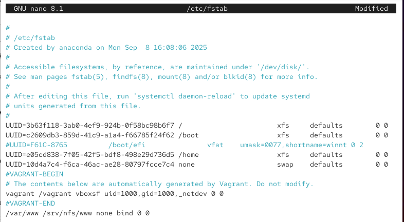

Создание bind-монтирования

## Подключение каталогов к дереву NFS

Повторно экспортируем каталоги, указанные в файле /etc/exports.

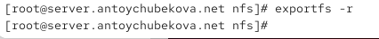

Экспорт каталогов

## Подключение каталогов к дереву NFS

На клиенте проверим каталог /mnt/nfs. Тут также указан каталог www.

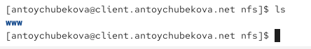

Содержимое /mnt/nfs

## Подключение каталогов для работы пользователей

На сервере под пользователем antoychubekova в его домашнем каталоге создадим каталог common с полными правами доступа только для этого пользователя, а в нём файл antoychubekova@server.txt.

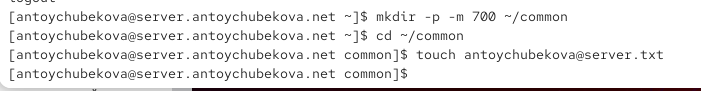

Создание каталога и файла

## Подключение каталогов для работы пользователей

На сервере создадим общий каталог для работы пользователя antoychubekova по сети. Подмонтируем каталог common пользователя antoychubekova в NFS.

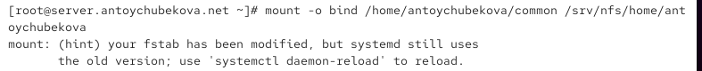

Создание каталога и монтирование